# Brain_MRI_Classification_HW (4)

In the name of God

Intelligent Analysis of Biomedical Images  
sharif university of technology, CE department  
Homework 1.2  
Deep learning method

**First-Name:** Javad

**Last-Name:** Razi Giglou

**Student-Id:** 401204354

# Download Data

##### Execute the cell below to download the data required for your homework.

```python
%pip install gdown
%pip install scikit-image
%pip install seaborn
```

```python
import gdown

url = 'https://drive.google.com/uc?id=1-2zT-_bKjN2o2QxwSviFwbCzcWE2PnkJ'

output = 'dataset.zip'
gdown.download(url, output, quiet=False)
```

```
Downloading...
From (uriginal): https://drive.google.com/uc?id=1-2zT-_bKjN2o2QxwSviFwbCzcWE2PnkJ
From (redirected): https://drive.google.com/uc?id=1-2zT-_bKjN2o2QxwSviFwbCzcWE2PnkJ&confirm=t&uuid=38521d4b-b8ca-4da6-ac32-66133cfc8d5c
To: /home/jovyan/workspace/dataset.zip
```

```
'dataset.zip'
```

```python
! unzip -u -q dataset.zip
```

# Import

```python
import os
import numpy as np
import seaborn as sns
import zipfile
import pandas as pd
import matplotlib.pyplot as plt
import cv2
from skimage import io
import torch
import random
import pandas as pd
import random
import glob
from sklearn.preprocessing import StandardScaler, normalize
from IPython.display import display
```

# Config

```python
RANDOM_SEED = 42 # Must be used wherever can be used

torch.manual_seed(RANDOM_SEED)
random.seed(RANDOM_SEED)
np.random.seed(RANDOM_SEED)
```

```python
device = torch.device('cuda' if torch.cuda.is_available() else 'cpu')
device
```

```
device(type='cuda')
```

# Load and Process Data

```python
data = pd.read_csv('patient_ids.csv')
data.info()
```

```
<class 'pandas.core.frame.DataFrame'>
RangeIndex: 110 entries, 0 to 109
Data columns (total 1 columns):
 #   Column  Non-Null Count  Dtype
---  ------  --------------  -----
 0   id      110 non-null    object
dtypes: object(1)
memory usage: 1008.0+ bytes
```

```python
data.head()
```

|  | id |
| --- | --- |
| 0 | TCGA_CS_4941 |
| 1 | TCGA_CS_4942 |
| 2 | TCGA_CS_4943 |
| 3 | TCGA_CS_4944 |
| 4 | TCGA_CS_5393 |

### **Exercise 1 (5 points)**:

##### Please use the patient_ids.csv file and the images inside the mri_scans folder to generate a Pandas dataframe named mri_df. This dataframe should have columns labeled "patient_id", "image_path", and "mask_path".

```python
import pandas as pd
import glob

mri_df = pd.DataFrame()
mri_df['patient_id'] = data['id']

# Create pairs of 'image_path' and 'mask_path' for each patient
mri_df['path_pairs'] = mri_df['patient_id'].apply(lambda patient_id: list(zip(glob.glob(f'./mri_scans/{patient_id}_*/*[!_mask].tif'), glob.glob(f'./mri_scans/{patient_id}_*/*_mask.tif'))))

mri_df = mri_df.explode('path_pairs')

# Create separate columns for 'image_path' and 'mask_path'
mri_df[['image_path', 'mask_path']] = pd.DataFrame(mri_df['path_pairs'].tolist(), index=mri_df.index)

# Drop the 'path_pairs' column as it's no longer needed
mri_df = mri_df.drop(columns=['path_pairs'])

assert len(mri_df) == 3929
mri_df.head()
```

|  | patient_id | image_path | mask_path |
| --- | --- | --- | --- |
| 0 | TCGA_CS_4941 | ./mri_scans/TCGA_CS_4941_19960909/TCGA_CS_4941... | ./mri_scans/TCGA_CS_4941_19960909/TCGA_CS_4941... |
| 0 | TCGA_CS_4941 | ./mri_scans/TCGA_CS_4941_19960909/TCGA_CS_4941... | ./mri_scans/TCGA_CS_4941_19960909/TCGA_CS_4941... |
| 0 | TCGA_CS_4941 | ./mri_scans/TCGA_CS_4941_19960909/TCGA_CS_4941... | ./mri_scans/TCGA_CS_4941_19960909/TCGA_CS_4941... |
| 0 | TCGA_CS_4941 | ./mri_scans/TCGA_CS_4941_19960909/TCGA_CS_4941... | ./mri_scans/TCGA_CS_4941_19960909/TCGA_CS_4941... |
| 0 | TCGA_CS_4941 | ./mri_scans/TCGA_CS_4941_19960909/TCGA_CS_4941... | ./mri_scans/TCGA_CS_4941_19960909/TCGA_CS_4941... |

### **Exercise 2 (3 points)**:

##### Append a has_cancer column to the mri_df DataFrame, with values 0 indicating the absence of cancer and 1 indicating the presence of cancer. Then, convert the column to string type.

```python
def is_cancerous(mask_path):
    mask = io.imread(mask_path)
    return int(np.any(mask))

mri_df['has_cancer'] = mri_df['mask_path'].apply(lambda x: is_cancerous(x))
mri_df.head()
```

|  | patient_id | image_path | mask_path | has_cancer |
| --- | --- | --- | --- | --- |
| 0 | TCGA_CS_4941 | ./mri_scans/TCGA_CS_4941_19960909/TCGA_CS_4941... | ./mri_scans/TCGA_CS_4941_19960909/TCGA_CS_4941... | 1 |
| 0 | TCGA_CS_4941 | ./mri_scans/TCGA_CS_4941_19960909/TCGA_CS_4941... | ./mri_scans/TCGA_CS_4941_19960909/TCGA_CS_4941... | 0 |
| 0 | TCGA_CS_4941 | ./mri_scans/TCGA_CS_4941_19960909/TCGA_CS_4941... | ./mri_scans/TCGA_CS_4941_19960909/TCGA_CS_4941... | 0 |
| 0 | TCGA_CS_4941 | ./mri_scans/TCGA_CS_4941_19960909/TCGA_CS_4941... | ./mri_scans/TCGA_CS_4941_19960909/TCGA_CS_4941... | 0 |
| 0 | TCGA_CS_4941 | ./mri_scans/TCGA_CS_4941_19960909/TCGA_CS_4941... | ./mri_scans/TCGA_CS_4941_19960909/TCGA_CS_4941... | 0 |

# Exploratory Data Analysis

### **Exercise 3 (1 points)**:

##### Calculate the number of images exhibiting the presence and absence of cancer.

```python
cancer_counts = mri_df['has_cancer'].value_counts()
cancer_counts
```

```
0    2556
1    1373
Name: has_cancer, dtype: int64
```

### **Exercise 4 (3 points)**:

##### Determine the proportion of pixels designated as cancerous in relation to the total pixel count. Perform this calculation first for all MRI images and subsequently for images displaying signs of cancer.

```python
def count_pixels(mask_path):
    mask = io.imread(mask_path)
    return np.count_nonzero(mask), np.size(mask)

pixel_counts = mri_df['mask_path'].apply(lambda x: count_pixels(x))
cancerous_pixels_count = np.sum([x[0] for x in pixel_counts])
total_pixels_count = np.sum([x[1] for x in pixel_counts])

print(f'The proportion of cancerous pixels = {100 * cancerous_pixels_count / total_pixels_count}%')
print(f'The proportion of non-cancerous pixels = {100 * (total_pixels_count - cancerous_pixels_count) / total_pixels_count}%')
```

```
The proportion of cancerous pixels = 1.0298824334575434%
The proportion of non-cancerous pixels = 98.97011756654246%
```

# Visualization

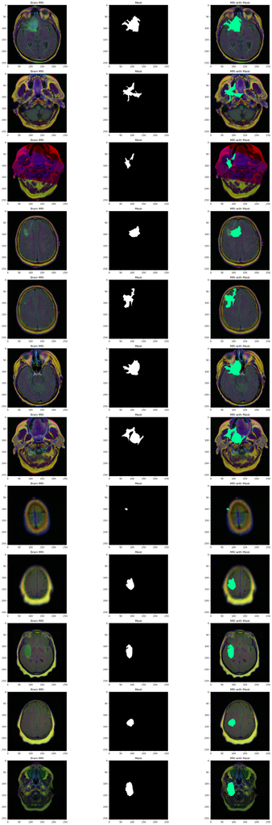

```python
import matplotlib.pyplot as plt

count = 0
fig, axs = plt.subplots(12, 3, figsize=(20, 50))

for idx, row in mri_df.iterrows():
    if row['has_cancer'] == 1:
        img = io.imread(row['image_path'])
        axs[count][0].title.set_text("Brain MRI")
        axs[count][0].imshow(img)

        mask = io.imread(row['mask_path'])
        axs[count][1].title.set_text("Mask")
        axs[count][1].imshow(mask, cmap='gray')

        img[mask == 255] = (0, 255, 150)
        axs[count][2].title.set_text("MRI with Mask")
        axs[count][2].imshow(img)
        count += 1

    if count == 12:
        break

fig.tight_layout()
plt.show()
```

# Create Dataset & DataLoader

#### Splitting To Train/Test/Val

##### Also, you are free to modify the below code.

```python
# Create Dataset & DataLoader
from sklearn.model_selection import train_test_split

mri_df = mri_df.sample(frac=1.0, random_state=RANDOM_SEED)

# Splitting To Train/Test/Val
mri_df['has_cancer'] = mri_df['has_cancer'].apply(lambda x: str(x))

X_train, X_test, y_train, y_test = train_test_split(
    mri_df[['image_path']],
    mri_df[['has_cancer']],
    test_size=0.05,
    random_state=RANDOM_SEED,
    stratify = mri_df['has_cancer'],
)

train_df = pd.concat([X_train, y_train], axis=1).reset_index(drop=True)
test_df = pd.concat([X_test, y_test], axis=1).reset_index(drop=True)

X_train, X_val, y_train, y_val = train_test_split(
    train_df[['image_path']],
    train_df[['has_cancer']],
    test_size=0.1,
    random_state=RANDOM_SEED,
    stratify = train_df['has_cancer']
)

train_df = pd.concat([X_train, y_train], axis=1).reset_index(drop=True)
val_df = pd.concat([X_val, y_val], axis=1).reset_index(drop=True)

print(f'train df count: {len(train_df)}')
print(f'test df count: {len(test_df)}')
print(f'validation df count: {len(val_df)}')
```

```
train df count: 3358
test df count: 197
validation df count: 374
```

```python
print(train_df['has_cancer'].value_counts())
print(val_df['has_cancer'].value_counts())
print(test_df['has_cancer'].value_counts())
```

```
0    2185
1    1173
Name: has_cancer, dtype: int64
0    243
1    131
Name: has_cancer, dtype: int64
0    128
1     69
Name: has_cancer, dtype: int64
```

### **Exercise 5 (5 points)**:

##### Complete the code for the functions of BrainMRIDataset class (mask pixel values must be either 0 or 1).

```python
import torch
from torch.utils.data import Dataset, DataLoader
from torchvision import transforms
import cv2

class BrainMRIDataset(Dataset):
    def __init__(self, dataframe, image_transform=None):
        self.dataframe = dataframe
        self.image_transform = image_transform

    def __len__(self):
        return len(self.dataframe)

    def __getitem__(self, idx):
        image_path = self.dataframe.iloc[idx]['image_path']
        image = cv2.imread(image_path)
        image = cv2.cvtColor(image, cv2.COLOR_BGR2RGB)

        has_cancer = int(self.dataframe.iloc[idx]['has_cancer'])

        if self.image_transform:
            image = self.image_transform(image)

        return image, has_cancer

BATCH_SIZE = 32

train_transform = transforms.Compose([
    transforms.ToPILImage(),
    transforms.Resize((224, 224)),
    transforms.ToTensor(),
])

test_transform = transforms.Compose([
    transforms.ToPILImage(),
    transforms.Resize((224, 224)),
    transforms.ToTensor(),
])

train_dataset = BrainMRIDataset(
    train_df,
    image_transform=train_transform,
)
val_dataset = BrainMRIDataset(
    val_df,
    image_transform=test_transform,
)
test_dataset = BrainMRIDataset(
    test_df,
    image_transform=test_transform,
)

train_dataloader = DataLoader(train_dataset, batch_size=BATCH_SIZE, shuffle=True)
val_dataloader = DataLoader(val_dataset, batch_size=BATCH_SIZE, shuffle=True)
test_dataloader = DataLoader(test_dataset, batch_size=BATCH_SIZE, shuffle=False)
```

# **Classification**

##### You will be constructing a classification model designed to determine the presence of cancer in an image. To accomplish this task, utilize a pre-trained model (e.g., ResNet, Inception).

### **Exercise 6: Implement Your Classifier (15 points)**:

##### You are free to make every layer frozen or trainable.

```python
import torch
import torch.nn as nn
import torch.nn.functional as F
from torchvision import models

class Classifier(nn.Module):
    def __init__(self):
        super(Classifier, self).__init__()
        self.resnet = models.resnet34(pretrained=True)

        # Allow all layers to be trained
        for param in self.resnet.parameters():
            param.requires_grad = True

        self.resnet.fc = nn.Linear(self.resnet.fc.in_features, 2)

    def forward(self, x):
        x = self.resnet(x)
        return x


device = torch.device("cuda:0" if torch.cuda.is_available() else "cpu")
model = Classifier()
model.to(device)
```

```
Classifier(
  (resnet): ResNet(
    (conv1): Conv2d(3, 64, kernel_size=(7, 7), stride=(2, 2), padding=(3, 3), bias=False)
    (bn1): BatchNorm2d(64, eps=1e-05, momentum=0.1, affine=True, track_running_stats=True)
    (relu): ReLU(inplace=True)
    (maxpool): MaxPool2d(kernel_size=3, stride=2, padding=1, dilation=1, ceil_mode=False)
    (layer1): Sequential(
      (0): BasicBlock(
        (conv1): Conv2d(64, 64, kernel_size=(3, 3), stride=(1, 1), padding=(1, 1), bias=False)
        (bn1): BatchNorm2d(64, eps=1e-05, momentum=0.1, affine=True, track_running_stats=True)
        (relu): ReLU(inplace=True)
        (conv2): Conv2d(64, 64, kernel_size=(3, 3), stride=(1, 1), padding=(1, 1), bias=False)
        (bn2): BatchNorm2d(64, eps=1e-05, momentum=0.1, affine=True, track_running_stats=True)
      )
      (1): BasicBlock(
        (conv1): Conv2d(64, 64, kernel_size=(3, 3), stride=(1, 1), padding=(1, 1), bias=False)
        (bn1): BatchNorm2d(64, eps=1e-05, momentum=0.1, affine=True, track_running_stats=True)
        (relu): ReLU(inplace=True)
        (conv2): Conv2d(64, 64, kernel_size=(3, 3), stride=(1, 1), padding=(1, 1), bias=False)
        (bn2): BatchNorm2d(64, eps=1e-05, momentum=0.1, affine=True, track_running_stats=True)
      )
      (2): BasicBlock(
        (conv1): Conv2d(64, 64, kernel_size=(3, 3), stride=(1, 1), padding=(1, 1), bias=False)
        (bn1): BatchNorm2d(64, eps=1e-05, momentum=0.1, affine=True, track_running_stats=True)
        (relu): ReLU(inplace=True)
        (conv2): Conv2d(64, 64, kernel_size=(3, 3), stride=(1, 1), padding=(1, 1), bias=False)
        (bn2): BatchNorm2d(64, eps=1e-05, momentum=0.1, affine=True, track_running_stats=True)
      )
    )
    (layer2): Sequential(
      (0): BasicBlock(
        (conv1): Conv2d(64, 128, kernel_size=(3, 3), stride=(2, 2), padding=(1, 1), bias=False)
        (bn1): BatchNorm2d(128, eps=1e-05, momentum=0.1, affine=True, track_running_stats=True)
        (relu): ReLU(inplace=True)
        (conv2): Conv2d(128, 128, kernel_size=(3, 3), stride=(1, 1), padding=(1, 1), bias=False)
        (bn2): BatchNorm2d(128, eps=1e-05, momentum=0.1, affine=True, track_running_stats=True)
        (downsample): Sequential(
          (0): Conv2d(64, 128, kernel_size=(1, 1), stride=(2, 2), bias=False)
          (1): BatchNorm2d(128, eps=1e-05, momentum=0.1, affine=True, track_running_stats=True)
        )
```

[output cut: 87 more lines]

```
        (conv2): Conv2d(512, 512, kernel_size=(3, 3), stride=(1, 1), padding=(1, 1), bias=False)
        (bn2): BatchNorm2d(512, eps=1e-05, momentum=0.1, affine=True, track_running_stats=True)
      )
      (2): BasicBlock(
        (conv1): Conv2d(512, 512, kernel_size=(3, 3), stride=(1, 1), padding=(1, 1), bias=False)
        (bn1): BatchNorm2d(512, eps=1e-05, momentum=0.1, affine=True, track_running_stats=True)
        (relu): ReLU(inplace=True)
        (conv2): Conv2d(512, 512, kernel_size=(3, 3), stride=(1, 1), padding=(1, 1), bias=False)
        (bn2): BatchNorm2d(512, eps=1e-05, momentum=0.1, affine=True, track_running_stats=True)
      )
    )
    (avgpool): AdaptiveAvgPool2d(output_size=(1, 1))
    (fc): Linear(in_features=512, out_features=2, bias=True)
  )
)
```

### **Exercise 7 (5 points)**:

##### Define your optimizer, criterion, and learning rate scheduler.

##### **Note**: Do not forget to address the class imbalance problem.

```python
import torch.optim as optim
from torch.optim import lr_scheduler
from torch.cuda.amp import autocast, GradScaler
from sklearn.utils.class_weight import compute_class_weight

# Get the unique classes and their corresponding weights
classes = np.unique(train_df['has_cancer'])
weights = compute_class_weight(class_weight = 'balanced', classes = classes, y = train_df['has_cancer'])

# Convert to a PyTorch tensor
class_weights = torch.tensor(weights, dtype=torch.float).to(device)

# Use in your loss function
criterion = nn.CrossEntropyLoss(weight=class_weights)

lr = 0.001
optimizer = optim.Adam(model.parameters(), lr=lr)
scheduler = lr_scheduler.StepLR(optimizer, step_size=5, gamma=0.1)
```

### **Exercise 8 & 9 (35 points)**:

##### Complete the code for training and validation.

```python
from sklearn.metrics import precision_score, f1_score

def train_one_epoch(model, loader, criterion, optimizer, device):
    model.train()
    running_loss = 0.0
    scaler = GradScaler()  # Initialize GradScaler

    all_labels = []
    all_predictions = []

    for inputs, labels in loader:
        inputs = inputs.to(device)
        labels = labels.to(device)

        optimizer.zero_grad()

        # Use autocast to enable mixed precision
        with autocast():
            outputs = model(inputs)
            loss = criterion(outputs, labels)

        # Use a scaler to scale the loss so that gradients do not underflow
        scaler.scale(loss).backward()
        scaler.step(optimizer)
        scaler.update()

        running_loss += loss.item() * inputs.size(0)

        _, preds = torch.max(outputs, 1)
        all_labels.extend(labels.detach().cpu().numpy())
        all_predictions.extend(preds.detach().cpu().numpy())

    precision = precision_score(all_labels, all_predictions, average='macro')
    f1 = f1_score(all_labels, all_predictions, average='macro')

    return running_loss / len(loader), precision, f1


def validate_one_epoch(model, loader, criterion, device):
    model.eval()
    running_loss = 0.0
    correct_predictions = 0

    all_labels = []
    all_predictions = []

    with torch.no_grad():
        for inputs, labels in loader:
            inputs = inputs.to(device)
            labels = labels.to(device)

            outputs = model(inputs)
            _, preds = torch.max(outputs, 1)
            loss = criterion(outputs, labels)

            running_loss += loss.item() * inputs.size(0)
            correct_predictions += torch.sum(preds == labels.data)

            all_labels.extend(labels.detach().cpu().numpy())
            all_predictions.extend(preds.detach().cpu().numpy())

    epoch_acc = correct_predictions.double() / len(loader.dataset)

    precision = precision_score(all_labels, all_predictions, average='macro')
    f1 = f1_score(all_labels, all_predictions, average='macro')

    return running_loss / len(loader), epoch_acc, precision, f1
```

```python
num_epochs = 10
for epoch in range(num_epochs):
    train_loss, train_precision, train_f1 = train_one_epoch(model, train_dataloader, criterion, optimizer, device)
    val_loss, val_acc, val_precision, val_f1 = validate_one_epoch(model, val_dataloader, criterion, device)

    # Step the scheduler
    scheduler.step()

    print(f"Epoch [{epoch+1}/{num_epochs}] - "
          f"Loss: {train_loss:.4f} - "
          f"Train Precision: {train_precision:.4f} - "
          f"Train F1: {train_f1:.4f} - "
          f"Validation Loss: {val_loss:.4f} - "
          f"Validation Accuracy: {val_acc:.4f} - "
          f"Validation Precision: {val_precision:.4f} - "
          f"Validation F1: {val_f1:.4f}")
```

```
Epoch [1/10] - Loss: 24.2857 - Train Precision: 0.5070 - Train F1: 0.5069 - Validation Loss: 21.9881 - Validation Accuracy: 0.3770 - Validation Precision: 0.5850 - Validation F1: 0.3120
Epoch [2/10] - Loss: 22.5053 - Train Precision: 0.5117 - Train F1: 0.5101 - Validation Loss: 21.6498 - Validation Accuracy: 0.4251 - Validation Precision: 0.4877 - Validation F1: 0.4226
Epoch [3/10] - Loss: 22.6543 - Train Precision: 0.5305 - Train F1: 0.5236 - Validation Loss: 24.8683 - Validation Accuracy: 0.5481 - Validation Precision: 0.5224 - Validation F1: 0.5210
Epoch [4/10] - Loss: 22.5184 - Train Precision: 0.5182 - Train F1: 0.5084 - Validation Loss: 22.4270 - Validation Accuracy: 0.3930 - Validation Precision: 0.5059 - Validation F1: 0.3632
Epoch [5/10] - Loss: 22.2059 - Train Precision: 0.5265 - Train F1: 0.5258 - Validation Loss: 22.5304 - Validation Accuracy: 0.4813 - Validation Precision: 0.5287 - Validation F1: 0.4813
Epoch [6/10] - Loss: 22.0094 - Train Precision: 0.5491 - Train F1: 0.5491 - Validation Loss: 21.4315 - Validation Accuracy: 0.5561 - Validation Precision: 0.5498 - Validation F1: 0.5428
Epoch [7/10] - Loss: 21.8675 - Train Precision: 0.5513 - Train F1: 0.5516 - Validation Loss: 21.4639 - Validation Accuracy: 0.5775 - Validation Precision: 0.5477 - Validation F1: 0.5477
Epoch [8/10] - Loss: 21.8782 - Train Precision: 0.5521 - Train F1: 0.5505 - Validation Loss: 21.4874 - Validation Accuracy: 0.5642 - Validation Precision: 0.5480 - Validation F1: 0.5449
Epoch [9/10] - Loss: 21.7719 - Train Precision: 0.5677 - Train F1: 0.5675 - Validation Loss: 21.7009 - Validation Accuracy: 0.5053 - Validation Precision: 0.5191 - Validation F1: 0.4999
Epoch [10/10] - Loss: 21.7809 - Train Precision: 0.5611 - Train F1: 0.5579 - Validation Loss: 21.6997 - Validation Accuracy: 0.5321 - Validation Precision: 0.5186 - Validation F1: 0.5136
```

# **Exercise 10: Evaluation (30 points)**:

##### Evaluate your model with the metrics you defined earlier on your test data (f1 > 0.7 is required).

```python
all_labels = []
all_predictions = []

with torch.no_grad():
    for inputs, labels in test_dataloader:
        inputs = inputs.to(device)
        labels = labels.to(device)

        outputs = model(inputs)
        _, preds = torch.max(outputs, 1)

        all_labels.extend(labels.detach().cpu().numpy())
        all_predictions.extend(preds.detach().cpu().numpy())
```

### Classificatin Report

```python
from sklearn.metrics import classification_report

report = classification_report(all_labels, all_predictions, output_dict = True)

display(pd.DataFrame(report))
```

|  | 0 | 1 | accuracy | macro avg | weighted avg |
| --- | --- | --- | --- | --- | --- |
| precision | 0.728155 | 0.436170 | 0.588832 | 0.582163 | 0.625886 |
| recall | 0.585938 | 0.594203 | 0.588832 | 0.590070 | 0.588832 |
| f1-score | 0.649351 | 0.503067 | 0.588832 | 0.576209 | 0.598114 |
| support | 128.000000 | 69.000000 | 0.588832 | 197.000000 | 197.000000 |

# **Exercise 11: Report (5 points)**:

##### Visualize the confusion matrix and find the weaknesses of your model (describe it in 2 lines).

### Confusion Matrix

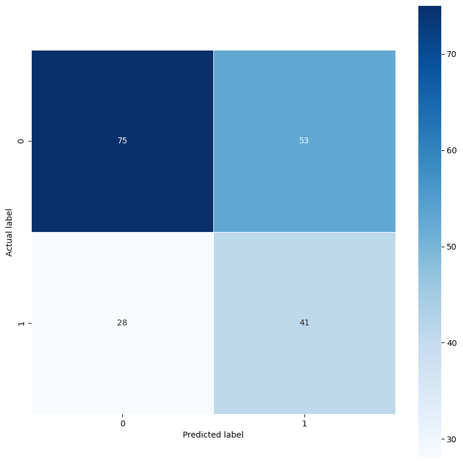

```python
from sklearn.metrics import confusion_matrix
import seaborn as sns

cm = confusion_matrix(all_labels, all_predictions)
plt.figure(figsize=(10,10))
sns.heatmap(cm, annot=True, fmt=".0f", linewidths=.5, square = True, cmap = 'Blues')
plt.ylabel('Actual label')
plt.xlabel('Predicted label')
plt.show()
```

### Normalized Confusion Matrix

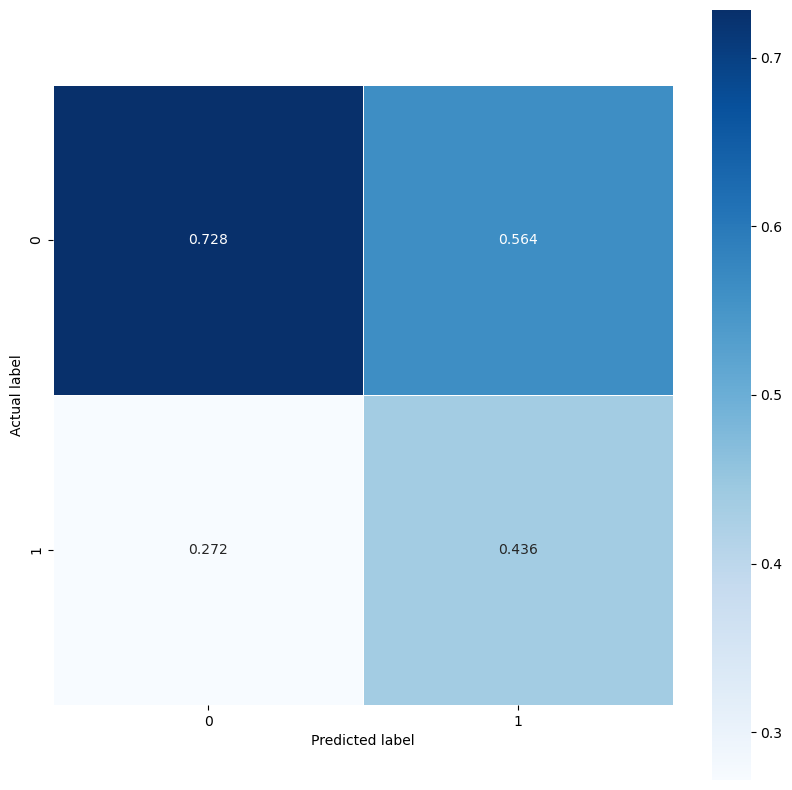

```python
from sklearn.metrics import confusion_matrix
import seaborn as sns

cm = confusion_matrix(all_labels, all_predictions, normalize='pred')
plt.figure(figsize=(10,10))
sns.heatmap(cm, annot=True, fmt=".3f", linewidths=.5, square = True, cmap = 'Blues')
plt.ylabel('Actual label')
plt.xlabel('Predicted label')
plt.show()
```

# **Exercise 12: Feature Space Visualization (20 points)**:

##### You have trained and evaluated your model. Now, for each image in the trainset, calculate it's "feature space" (After Applying Final Pooling).

##### Use **TSNE** to visualize the points in a 2D plane (Set color of each point based on it's class).

```python
from sklearn.manifold import TSNE

def get_features(dataloader):
    model.eval()
    features = []
    labels = []

    with torch.no_grad():
        for inputs, label in dataloader:
            inputs = inputs.to(device)

            # Get the output of the second last layer in the model
            x = model.resnet.conv1(inputs)
            x = model.resnet.bn1(x)
            x = model.resnet.relu(x)
            x = model.resnet.maxpool(x)

            x = model.resnet.layer1(x)
            x = model.resnet.layer2(x)
            x = model.resnet.layer3(x)
            feature = model.resnet.layer4(x)

            feature = torch.nn.functional.avg_pool2d(feature, feature.size()[2:]).reshape(feature.size()[0], -1)
            features.append(feature.cpu().numpy())
            labels.append(label)

    return np.vstack(features), labels

features_train, labels_train = get_features(train_dataloader)
```

```python
tsne = TSNE(n_components=2).fit_transform(features_train)
```

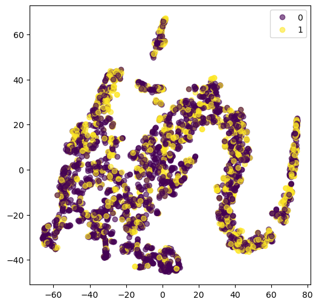

```python
plt.figure(figsize=(6,6))

labels_train_np = np.concatenate([label.numpy().flatten() for label in labels_train])
scatter = plt.scatter(tsne[:,0], tsne[:,1], c=labels_train_np , cmap='viridis', alpha=0.6)

plt.legend(*scatter.legend_elements())
plt.show()
```